# Examen Interciclo

**Oscar Pizarro**

**Ecuador**

Recuperacion del sector economico

```python
import pandas as pd
import numpy as np
from datetime import datetime,timedelta
from sklearn.metrics import mean_squared_error
from scipy.optimize import curve_fit
from scipy.optimize import fsolve
from sklearn import linear_model
import matplotlib.pyplot as plt
%matplotlib inline

diapred=7
url = 'RecEcCovid.csv'
df = pd.read_csv(url)
```

## Modelos matematicos

**Modelo Logistico**

```
Prediccion 1 Semana
Dia 1 = 1243.455128405933 --> Total:  4805.455128405933
Dia 2 = 1268.300894186238 --> Total:  4830.300894186238
Dia 3 = 1292.5175851649078 --> Total:  4854.517585164907
Dia 4 = 1316.1362716218114 --> Total:  4878.136271621812
Dia 5 = 1339.1857773410575 --> Total:  4901.1857773410575
Dia 6 = 1361.6928910971396 --> Total:  4923.69289109714
Dia 7 = 1383.6825538255039 --> Total:  4945.682553825503
```

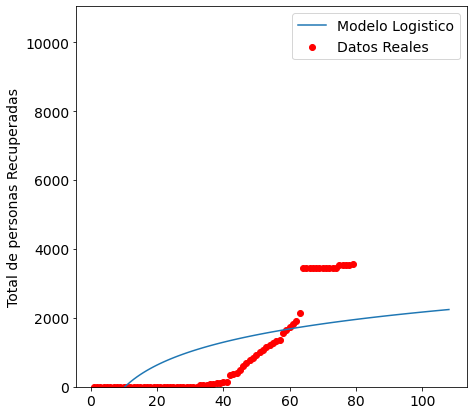

```python
y = list(df.iloc [:, 1])
x = list(df.iloc [:, 0])
def logistico(x,a,b):
    return a+b*np.log(x)
exp_fit = curve_fit(logistico,x,y)
pred_x = list(range(min(x),max(x)+30))

print("Prediccion 1 Semana")
for i in range(diapred):
    print("Dia",i+1,"=",logistico(38+i,exp_fit[0][0],exp_fit[0][1]),"--> Total: ",logistico(38+i,exp_fit[0][0],exp_fit[0][1])+3562)

plt.rcParams['figure.figsize'] = [7, 7]
plt.rc('font', size=14)
plt.scatter(x,y,label="Datos Reales",color="red")
plt.plot(pred_x, [logistico(i,exp_fit[0][0],exp_fit[0][1]) for i in pred_x], label="Modelo Logistico" )
plt.legend()
plt.ylabel("Total de personas Recuperadas")
plt.ylim((min(y)*0.9,max(y)*3.1))
plt.show()
```

```
Prediccion 1 mes
Dia 1 = 1243.455128405933 --> Total:  4805.455128405933
Dia 2 = 1268.300894186238 --> Total:  4830.300894186238
Dia 3 = 1292.5175851649078 --> Total:  4854.517585164907
Dia 4 = 1316.1362716218114 --> Total:  4878.136271621812
Dia 5 = 1339.1857773410575 --> Total:  4901.1857773410575
Dia 6 = 1361.6928910971396 --> Total:  4923.69289109714
Dia 7 = 1383.6825538255039 --> Total:  4945.682553825503
Dia 8 = 1405.1780247570787 --> Total:  4967.178024757079
Dia 9 = 1426.2010292915893 --> Total:  4988.201029291589
Dia 10 = 1446.7718909666241 --> Total:  5008.771890966624
Dia 11 = 1466.909649531969 --> Total:  5028.909649531969
Dia 12 = 1486.6321668485916 --> Total:  5048.632166848592
Dia 13 = 1505.9562220884632 --> Total:  5067.956222088464
Dia 14 = 1524.8975975067037 --> Total:  5086.897597506704
Dia 15 = 1543.4711558846843 --> Total:  5105.471155884685
Dia 16 = 1561.6909105961895 --> Total:  5123.6909105961895
Dia 17 = 1579.57008912414 --> Total:  5141.5700891241395
Dia 18 = 1597.1211907490597 --> Total:  5159.12119074906
Dia 19 = 1614.3560390395037 --> Total:  5176.356039039503
Dia 20 = 1631.28582969655 --> Total:  5193.28582969655
Dia 21 = 1647.9211742372468 --> Total:  5209.921174237246
Dia 22 = 1664.272139943856 --> Total:  5226.272139943856
Dia 23 = 1680.3482864555244 --> Total:  5242.348286455524
Dia 24 = 1696.1586993354222 --> Total:  5258.158699335422
Dia 25 = 1711.712020908461 --> Total:  5273.7120209084605
Dia 26 = 1727.016478631674 --> Total:  5289.0164786316745
Dia 27 = 1742.0799112304144 --> Total:  5304.079911230414
Dia 28 = 1756.9097928082392 --> Total:  5318.909792808239
Dia 29 = 1771.5132551161205 --> Total:  5333.5132551161205
Dia 30 = 1785.8971081470854 --> Total:  5347.897108147085
```

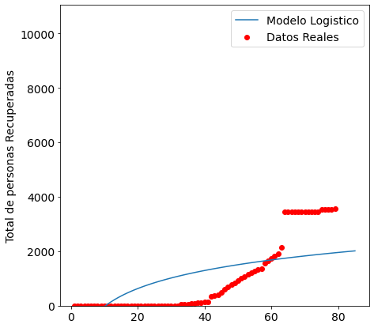

```python
y = list(df.iloc [:, 1])
x = list(df.iloc [:, 0])
def logistico(x,a,b):
    return a+b*np.log(x)
exp_fit = curve_fit(logistico,x,y)
pred_x = list(range(min(x),max(x)+7))

print("Prediccion 1 mes")
diap=30
for i in range(diap):
    print("Dia",i+1,"=",logistico(38+i,exp_fit[0][0],exp_fit[0][1]),"--> Total: ",logistico(38+i,exp_fit[0][0],exp_fit[0][1])+3562)

plt.rcParams['figure.figsize'] = [7, 7]
plt.rc('font', size=14)
plt.scatter(x,y,label="Datos Reales",color="red")
plt.plot(pred_x, [logistico(i,exp_fit[0][0],exp_fit[0][1]) for i in pred_x], label="Modelo Logistico" )
plt.legend()
plt.ylabel("Total de personas Recuperadas")
plt.ylim((min(y)*0.9,max(y)*3.1))
plt.show()
```

**Modelo Polinomial**

```
PREDICCION 1 SEMANA
Dia 1 =  134.62609123081737 -> Total: 3696.6260912308176
Dia 2 =  162.70866930793898 -> Total: 3724.708669307939
Dia 3 =  194.89002300404 -> Total: 3756.89002300404
Dia 4 =  231.5031861377655 -> Total: 3793.5031861377656
Dia 5 =  272.8759623817449 -> Total: 3834.875962381745
Dia 6 =  319.3268406144324 -> Total: 3881.3268406144325
Dia 7 =  371.16062116057725 -> Total: 3933.160621160577
```

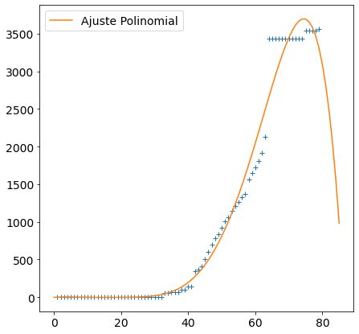

```python
y = list(df.iloc [:, 1])
x = list(df.iloc [:, 0])

muestra = {}
for dias in range(1,7):
  z = np.polyfit(x, y, dias, full=True)
  muestra[dias] = z

plt.plot(x, y, '+')
xp=np.array(range(0,86))
for dias, contagio in muestra.items():
  coefs, error, *_ = contagio
  p = np.poly1d(coefs)

plt.plot(xp, p(xp), "-", label="Ajuste Polinomial"  )
plt.legend()

print("PREDICCION 1 SEMANA")
for i in range(diapred):
    print("Dia",i+1,"= ",p(38+i),"-> Total:",p(38+i)+3562 )
```

```
Prediccion 1 mes
Dia 1 =  73.7588599295525 -> Total: 3635.7588599295523
Dia 2 =  98.20012774714178 -> Total: 3660.200127747142
Dia 3 =  139.97586924156644 -> Total: 3701.975869241566
Dia 4 =  199.6004161941578 -> Total: 3761.600416194158
Dia 5 =  274.38926653104977 -> Total: 3836.3892665310495
Dia 6 =  359.082567988916 -> Total: 3921.082567988916
Dia 7 =  447.21381114973633 -> Total: 4009.213811149736
Dia 8 =  532.8700492416149 -> Total: 4094.8700492416147
Dia 9 =  612.3394800884573 -> Total: 4174.339480088457
Dia 10 =  685.1215567956224 -> Total: 4247.121556795622
Dia 11 =  753.9140955041178 -> Total: 4315.9140955041175
Dia 12 =  823.470359255839 -> Total: 4385.470359255839
Dia 13 =  898.5841194953948 -> Total: 4460.584119495395
Dia 14 =  981.8074332283313 -> Total: 4543.807433228331
Dia 15 =  1071.725229882398 -> Total: 4633.725229882398
Dia 16 =  1162.6005957005075 -> Total: 4724.600595700507
Dia 17 =  1245.903694801352 -> Total: 4807.903694801352
Dia 18 =  1313.6732825585025 -> Total: 4875.673282558502
Dia 19 =  1362.9414635126625 -> Total: 4924.941463512662
Dia 20 =  1399.7959247872952 -> Total: 4961.795924787295
Dia 21 =  1441.292095447717 -> Total: 5003.292095447717
Dia 22 =  1513.645394562065 -> Total: 5075.645394562065
Dia 23 =  1645.9980791685987 -> Total: 5207.998079168598
Dia 24 =  1860.574627155593 -> Total: 5422.574627155593
Dia 25 =  2161.8055175952422 -> Total: 5723.805517595242
Dia 26 =  2528.4488528158863 -> Total: 6090.448852815886
Dia 27 =  2913.087759271478 -> Total: 6475.087759271478
Dia 28 =  3251.9615091995593 -> Total: 6813.961509199559
Dia 29 =  3484.6108430767954 -> Total: 7046.610843076795
Dia 30 =  3577.924600072307 -> Total: 7139.924600072307
7139
```

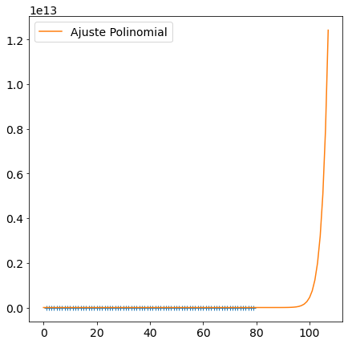

```python
muestra = {}
for dias in range(1,30):
  z = np.polyfit(x, y, dias, full=True)
  muestra[dias] = z

plt.plot(x, y, '+')
xp=np.array(range(0,108))
for dias, contagio in muestra.items():
  coefs, error, *_ = contagio
  p = np.poly1d(coefs)

plt.plot(xp, p(xp), "-", label="Ajuste Polinomial"  )
plt.legend()

print("Prediccion 1 mes")
diasp=30
for i in range(diasp):
    recu=0
    print("Dia",i+1,"= ",p(38+i),"-> Total:",p(38+i)+3562)
    recu=p(38+i)+3562
print(int(recu))
```

## Modelo Probabilistico

```python
rec=df["recuperados"][0:]
media= rec.mean()
print("La media es: ",media)
mediana= rec.median()
print("La mediana es: ",mediana)
```

```
La media es:  1024.5696202531647
La mediana es:  140.0
```

**Prediccion 7 dias**

```
La prediccion es de:  4542
```

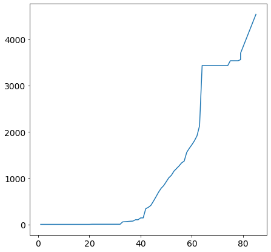

```python
yt=y
xt=x
prediccion_siguiente = int(yt[-1] + mediana)
for i in range(xt[-1], xt[-1]+7):
    xt.append(i)
    yt.append(int(yt[-1] + mediana))
print("La prediccion es de: ",yt[-1])
plt.plot(xt[0:], yt[0:])
plt.show()
```

**Prediccion 30 dias**

```
La prediccion es de:  8742
```

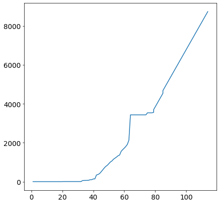

```python
yt=y
xt=x
prediccion_siguiente = int(yt[-1] + mediana)
for i in range(xt[-1], xt[-1]+30):
    xt.append(i)
    yt.append(int(yt[-1] + mediana))
print("La prediccion es de: ",yt[-1])
plt.plot(xt[0:], yt[0:])
plt.show()
```

### Conclusiones modelos Matematico y probabilistico

**Ventajas**

- modelo matematico
  - - Es una manera de ver como se compartan los datos.
  - - Se puede tener de manera grafica como afecta un evento.
  - - Se tiene diferentes modelos apra cada tiempo demuestra

**Desventajas**

- modelo matematico
  - - En ciertas ocaciones algunos modelos fallan
  - - la mayoria de ellos no son completamente exactos

**Comparacion**

El modelo matematico busca determinar la relación entre una variable dependiente Y con respecto a otras variables llamadas explicativas o independientes X. Asimismo, el modelo busca determinar cuál será el impacto sobre la variable Y ante un cambio en las variables explicativas X.

EL modelo probabilistico es un modelo matematico el cual estudia resultados de un supuesto caso aleatorio para ver como se va a ir comprtanto en el futuro y asi obtener un supuesto resultado para dar una solucion.

## Simulacion reinsercion laboral

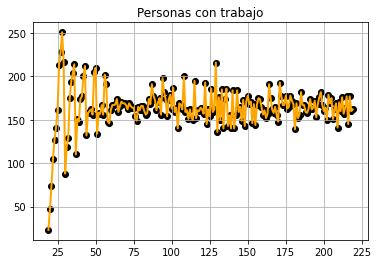

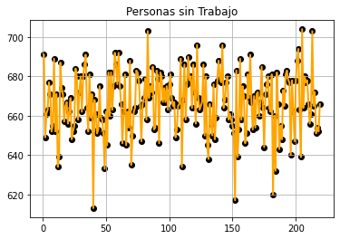

```
------------- Histograma---------
```

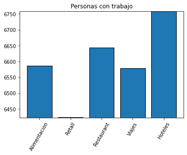

```python
import simpy
import random
import matplotlib.pyplot as pp
import numpy as np

%matplotlib inline


nempresa = 1
puestotrabajo = 2000
tiempo_evaluacion=7
Recuperados = int(recu)
crecimiento = int(media)
descanso =  7
teletrabajo = 14
teletrabajore= 5
DIAS_SIMULACION = 220


AL={}
RL={}
CM={}
VJ={}
HT={}
DMP={}
CMP={}



class Empresa(object):

    def __init__(self, env, PuestosT, name):
            self.env = env
            self.PuestosT=PuestosT
            self.vacante=simpy.Resource(env, PuestosT)
            self.name = name
    def empieza_teletrabajo(self,personarec):
        yield self.env.timeout(random.randint(teletrabajo-5, teletrabajo+5))

    def empieza_teletrabajore(self,personarec):
        yield self.env.timeout(random.randint(teletrabajore-3, teletrabajore+3))

    def empieza_descanso(self, personarec):
        yield self.env.timeout(random.randint(descanso-5, descanso+5))

    def revision(self, personarec):
        yield self.env.timeout(tiempo_evaluacion)


def trabajo(env, Empresa, personarec):
    arrive = env.now
    puestot = random.randint(1,100)
    if (puestot <= 35):
        yield env.process(Empresa.empieza_descanso(personarec))
        ttrabajo=random.randint(1,5)
        if (ttrabajo == 1):
            yield env.process(Empresa.empieza_teletrabajo(personarec))
            while True:
                with Empresa.vacante.request() as ptra:
                    dias_esperando = random.randint(1,220)
                    requerimiento = yield ptra | env.timeout(dias_esperando)
                    if ptra in requerimiento:
                        yield env.process(Empresa.revision(personarec))
                        evaluacion = random.randint(1,100)
                        if(evaluacion<=30):
                            yield env.process(Empresa.empieza_teletrabajore(personarec))
                        else:
                            CMP[env.now] = CMP[env.now] + 1 if env.now in CMP else  1
                            AL[env.now] = AL[env.now] + 1 if env.now in AL else  1
                            break

        if (ttrabajo == 2):
            yield env.process(Empresa.empieza_teletrabajo(personarec))
            while True:
                with Empresa.vacante.request() as ptra:
                    dias_esperando = random.randint(1,220)
                    requerimiento = yield ptra | env.timeout(dias_esperando)
                    if ptra in requerimiento:
                        yield env.process(Empresa.revision(personarec))
                        evaluacion = random.randint(1,100)
                        if(evaluacion<=30):
                            yield env.process(Empresa.empieza_teletrabajore(personarec))
                        else:
                            CMP[env.now] = CMP[env.now] + 1 if env.now in CMP else  1
                            RL[env.now] = RL[env.now] + 1 if env.now in RL else  1
                            break
        if (ttrabajo == 3):
            yield env.process(Empresa.empieza_teletrabajo(personarec))
            while True:
                with Empresa.vacante.request() as ptra:
                    dias_esperando = random.randint(1,220)
                    requerimiento = yield ptra | env.timeout(dias_esperando)
                    if ptra in requerimiento:
                        yield env.process(Empresa.revision(personarec))
                        evaluacion = random.randint(1,100)
                        if(evaluacion<=30):
                            yield env.process(Empresa.empieza_teletrabajore(personarec))
                        else:
                            CMP[env.now] = CMP[env.now] + 1 if env.now in CMP else  1
                            CM[env.now] = CM[env.now] + 1 if env.now in CM else  1
                            break
        if (ttrabajo == 4):
            yield env.process(Empresa.empieza_teletrabajo(personarec))
            while True:
                with Empresa.vacante.request() as ptra:
                    dias_esperando = random.randint(1,220)
                    requerimiento = yield ptra | env.timeout(dias_esperando)
                    if ptra in requerimiento:
                        yield env.process(Empresa.revision(personarec))
                        evaluacion = random.randint(1,100)
                        if(evaluacion<=30):
                            yield env.process(Empresa.empieza_teletrabajore(personarec))
                        else:
                            CMP[env.now] = CMP[env.now] + 1 if env.now in CMP else  1
                            VJ[env.now] = VJ[env.now] + 1 if env.now in VJ else  1
                            break
        if (ttrabajo == 5):
            yield env.process(Empresa.empieza_teletrabajo(personarec))
            while True:
                with Empresa.vacante.request() as ptra:
                    dias_esperando = random.randint(1,220)
                    requerimiento = yield ptra | env.timeout(dias_esperando)
                    if ptra in requerimiento:
                        yield env.process(Empresa.revision(personarec))
                        evaluacion = random.randint(1,100)
                        if(evaluacion<=30):
                            yield env.process(Empresa.empieza_teletrabajore(personarec))
                        else:
                            CMP[env.now] = CMP[env.now] + 1 if env.now in CMP else  1
                            HT[env.now] = HT[env.now] + 1 if env.now in HT else  1
                            break

    else:
        DMP[env.now] = DMP[env.now] + 1 if env.now in DMP else  1




def ejecutar(env, crecimiento, Recuperados):
    empresavac = Empresa(env,puestotrabajo,"ABC")
    for i in range(Recuperados):
        empresadisp(env, empresavac, i)
    personarec = Recuperados
    while True:
        yield env.timeout(1)
        for i in range(crecimiento):
            personarec += 1
            empresadisp(env, empresavac, personarec)

def empresadisp(env, empresavac, personarec):
    ptraba = 1
    if (ptraba == 1):
        env.process(trabajo(env, empresavac, personarec))


env=simpy.Environment()
env.process(ejecutar(env,crecimiento, Recuperados))
env.run(until=DIAS_SIMULACION)

jn=al+rl+cm+vj+ht/30
jl=al+rl+cm+vj+ht/60
ag=al+rl+cm+vj+ht/90
se=al+rl+cm+vj+ht/120
ot=al+rl+cm+vj+ht/150
nov=al+rl+cm+vj+ht/180
dic=al+rl+cm+vj+ht/210

datos=sorted(CMP.items())
x, y =zip(*datos)
pp.plot(x[1:],y[1:],linewidth=2,color='orange')
pp.scatter(x[1:],y[1:],color='black')
pp.title("Personas con trabajo")
pp.grid(True)
pp.show()

if (DMP):
    datos=sorted(DMP.items())
    x, y =zip(*datos)
    pp.plot(x[1:],y[1:],linewidth=2,color='orange')
    pp.scatter(x[1:],y[1:],color='black')
    pp.title("Personas sin Trabajo")
    pp.grid(True)
    pp.show()



print('------------- Histograma---------')
al=sum(AL.values())
rl=sum(RL.values())
cm=sum(CM.values())
vj=sum(VJ.values())
ht=sum(HT.values())
fechas = ['Alimentacion','Retall','Restaurant','Viajes','Hoteles']
primas = [al, rl, cm, vj, ht]
plt.bar(range(5), primas, edgecolor='black')
plt.xticks(range(5), fechas, rotation=60)
plt.title("Personas con trabajo")
plt.ylim(min(primas)-1, max(primas)+1)
plt.show()
```

```
------------- Histograma---------
```

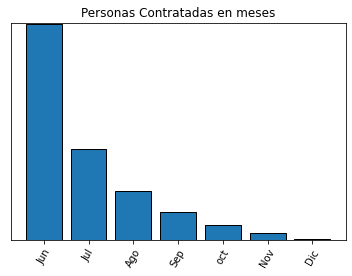

```python
print('------------- Histograma---------')
fechas = ['Jun','Jul','Ago','Sep','oct','Nov', 'Dic']
primas = [jn, jl, ag, se, ot, nov,dic ]
plt.bar(range(7), primas, edgecolor='black')
plt.xticks(range(7), fechas, rotation=60)
plt.yticks(range(5))
plt.title("Personas Contratadas en meses")
plt.ylim(min(primas)-1, max(primas)+1)
plt.show()
```